# Data 621 Homework 4

Sung Lee

11/18/2021

# Introduction

In this homework assignment, you will explore, analyze and model a data set containing approximately 8000 records representing a customer at an auto insurance company. Each record has two response variables. The first response variable, TARGET_FLAG, is a 1 or a 0. A “1” means that the person was in a car crash. A zero means that the person was not in a car crash. The second response variable is TARGET_AMT. This value is zero if the person did not crash their car. But if they did crash their car, this number will be a value greater than zero.

Your objective is to build multiple linear regression and binary logistic regression models on the training data to predict the probability that a person will crash their car and also the amount of money it will cost if the person does crash their car. You can only use the variables given to you (or variables that you derive from the variables provided). Below is a short description of the variables of interest in the data set:

| Variable | Description |
| --- | --- |
| INDEX | Identification Variable (do not use) |
| TARGET_FLAG | Was Car in a crash? 1=YES 0=NO |
| TARGET_AMT | If car was in a crash, what was the cost |
| AGE | Age of Driver |
| BLUEBOOK | Value of Vehicle |
| CAR_AGE | Vehicle Age |
| CAR_TYPE | Type of Car |
| CAR_USE | Vehicle Use |
| CLM_FREQ | # Claims (Past 5 Years) |
| EDUCATION | Max Education Level |
| HOMEKIDS | # Children at Home |
| HOME_VAL | Home Value |
| INCOME | Income |
| JOB | Job Category |
| KIDSDRIV | # Driving Children |
| MSTATUS | Marital Status |
| MVR_PTS | Motor Vehicle Record Points |
| OLDCLAIM | Total Claims (Past 5 Years) |
| PARENT1 | Single Parent |
| RED_CAR | A Red Car |
| REVOKED | License Revoked (Past 7 Years) |
| SEX | Gender |
| TIF | Time in Force |
| TRAVTIME | Distance to Work |
| URBANICITY | Home/Work Area |
| YOJ | Years on Job |

# Data Exploration

The following is a snippet of the training data:

| TARGET_FLAG | TARGET_AMT | KIDSDRIV | AGE | HOMEKIDS | YOJ | INCOME | PARENT1 | HOME_VAL | MSTATUS | SEX | EDUCATION | JOB | TRAVTIME | CAR_USE | BLUEBOOK | TIF | CAR_TYPE | RED_CAR | OLDCLAIM | CLM_FREQ | REVOKED | MVR_PTS | CAR_AGE | URBANICITY |
| --- | --- | --- | --- | --- | --- | --- | --- | --- | --- | --- | --- | --- | --- | --- | --- | --- | --- | --- | --- | --- | --- | --- | --- | --- |
| 0 | 0 | 0 | 60 | 0 | 11 | $67,349 | No | $0 | z_No | M | PhD | Professional | 14 | Private | $14,230 | 11 | Minivan | yes | $4,461 | 2 | No | 3 | 18 | Highly Urban/ Urban |
| 0 | 0 | 0 | 43 | 0 | 11 | $91,449 | No | $257,252 | z_No | M | z_High School | z_Blue Collar | 22 | Commercial | $14,940 | 1 | Minivan | yes | $0 | 0 | No | 0 | 1 | Highly Urban/ Urban |
| 0 | 0 | 0 | 35 | 1 | 10 | $16,039 | No | $124,191 | Yes | z_F | z_High School | Clerical | 5 | Private | $4,010 | 4 | z_SUV | no | $38,690 | 2 | No | 3 | 10 | Highly Urban/ Urban |
| 0 | 0 | 0 | 51 | 0 | 14 | NA | No | $306,251 | Yes | M | <High School | z_Blue Collar | 32 | Private | $15,440 | 7 | Minivan | yes | $0 | 0 | No | 0 | 6 | Highly Urban/ Urban |
| 0 | 0 | 0 | 50 | 0 | NA | $114,986 | No | $243,925 | Yes | z_F | PhD | Doctor | 36 | Private | $18,000 | 1 | z_SUV | no | $19,217 | 2 | Yes | 3 | 17 | Highly Urban/ Urban |
| 1 | 2946 | 0 | 34 | 1 | 12 | $125,301 | Yes | $0 | z_No | z_F | Bachelors | z_Blue Collar | 46 | Commercial | $17,430 | 1 | Sports Car | no | $0 | 0 | No | 0 | 7 | Highly Urban/ Urban |

The data needs to be cleaned. Before going to data preparation, let’s look at the unique values for the columns: `MSTATUS`,`SEX`,`EDUCATION`,`JOB`,`CAR_USE`,`CAR_TYPE`,`RED_CAR`,`REVOKED`,`URBANICITY`. With these unique values, I will see if I can convert them to binary values.

```
## $MSTATUS
## [1] "z_No" "Yes"
##
## $SEX
## [1] "M"   "z_F"
##
## $EDUCATION
## [1] "PhD"           "z_High School" "<High School"  "Bachelors"
## [5] "Masters"
##
## $JOB
## [1] "Professional"  "z_Blue Collar" "Clerical"      "Doctor"
## [5] "Lawyer"        "Manager"       NA              "Home Maker"
## [9] "Student"
##
## $CAR_USE
## [1] "Private"    "Commercial"
##
## $CAR_TYPE
## [1] "Minivan"     "z_SUV"       "Sports Car"  "Van"         "Panel Truck"
## [6] "Pickup"
##
## $RED_CAR
## [1] "yes" "no"
##
## $REVOKED
## [1] "No"  "Yes"
##
## $URBANICITY
## [1] "Highly Urban/ Urban"   "z_Highly Rural/ Rural"
```

# Data Preparation

In this section, I will prepare the data for evaluation.

## Data Types

The variables `Age`, `YOJ`, and `CAR_AGE` have missing values. In addition, various variables are classified as strings and the monetary values have to be converted to numeric values. This will be remedied in data preparation.

Here is a snippet of the new training data:

| TARGET_FLAG | TARGET_AMT | KIDSDRIV | AGE | HOMEKIDS | YOJ | INCOME | PARENT1 | HOME_VAL | MSTATUS | SEX | EDUCATION | JOB | TRAVTIME | CAR_USE | BLUEBOOK | TIF | CAR_TYPE | RED_CAR | OLDCLAIM | CLM_FREQ | REVOKED | MVR_PTS | CAR_AGE | URBANICITY |
| --- | --- | --- | --- | --- | --- | --- | --- | --- | --- | --- | --- | --- | --- | --- | --- | --- | --- | --- | --- | --- | --- | --- | --- | --- |
| 0 | 0 | 0 | 60 | 0 | 11 | 67349 | No | 0 | 0 | M | PhD | Professional | 14 | Private | 14230 | 11 | Minivan | 1 | 4461 | 2 | 0 | 3 | 18 | 1 |
| 0 | 0 | 0 | 43 | 0 | 11 | 91449 | No | 257252 | 0 | M | z_High School | z_Blue Collar | 22 | Commercial | 14940 | 1 | Minivan | 1 | 0 | 0 | 0 | 0 | 1 | 1 |
| 0 | 0 | 0 | 35 | 1 | 10 | 16039 | No | 124191 | 1 | z_F | z_High School | Clerical | 5 | Private | 4010 | 4 | z_SUV | 0 | 38690 | 2 | 0 | 3 | 10 | 1 |
| 0 | 0 | 0 | 51 | 0 | 14 | NA | No | 306251 | 1 | M | <High School | z_Blue Collar | 32 | Private | 15440 | 7 | Minivan | 1 | 0 | 0 | 0 | 0 | 6 | 1 |
| 0 | 0 | 0 | 50 | 0 | NA | 114986 | No | 243925 | 1 | z_F | PhD | Doctor | 36 | Private | 18000 | 1 | z_SUV | 0 | 19217 | 2 | 1 | 3 | 17 | 1 |
| 1 | 2946 | 0 | 34 | 1 | 12 | 125301 | Yes | 0 | 0 | z_F | Bachelors | z_Blue Collar | 46 | Commercial | 17430 | 1 | Sports Car | 0 | 0 | 0 | 0 | 0 | 7 | 1 |

```
##   TARGET_FLAG      TARGET_AMT        KIDSDRIV          AGE
##  Min.   :0.000   Min.   :     0   Min.   :0.000   Min.   :16.0
##  1st Qu.:0.000   1st Qu.:     0   1st Qu.:0.000   1st Qu.:39.0
##  Median :0.000   Median :     0   Median :0.000   Median :45.0
##  Mean   :0.264   Mean   :  1504   Mean   :0.171   Mean   :44.8
##  3rd Qu.:1.000   3rd Qu.:  1036   3rd Qu.:0.000   3rd Qu.:51.0
##  Max.   :1.000   Max.   :107586   Max.   :4.000   Max.   :81.0
##                                                   NA's   :6
##     HOMEKIDS          YOJ           INCOME         PARENT1
##  Min.   :0.000   Min.   : 0.0   Min.   :     0   Length:8161
##  1st Qu.:0.000   1st Qu.: 9.0   1st Qu.: 28097   Class :character
##  Median :0.000   Median :11.0   Median : 54028   Mode  :character
##  Mean   :0.721   Mean   :10.5   Mean   : 61898
##  3rd Qu.:1.000   3rd Qu.:13.0   3rd Qu.: 85986
##  Max.   :5.000   Max.   :23.0   Max.   :367030
##                  NA's   :454    NA's   :445
##     HOME_VAL         MSTATUS        SEX             EDUCATION
##  Min.   :     0   Min.   :0.0   Length:8161        Length:8161
##  1st Qu.:     0   1st Qu.:0.0   Class :character   Class :character
##  Median :161160   Median :1.0   Mode  :character   Mode  :character
##  Mean   :154867   Mean   :0.6
##  3rd Qu.:238724   3rd Qu.:1.0
##  Max.   :885282   Max.   :1.0
##  NA's   :464
##      JOB               TRAVTIME       CAR_USE             BLUEBOOK
##  Length:8161        Min.   :  5.0   Length:8161        Min.   : 1500
##  Class :character   1st Qu.: 22.0   Class :character   1st Qu.: 9280
##  Mode  :character   Median : 33.0   Mode  :character   Median :14440
##                     Mean   : 33.5                      Mean   :15710
##                     3rd Qu.: 44.0                      3rd Qu.:20850
##                     Max.   :142.0                      Max.   :69740
##
##       TIF          CAR_TYPE            RED_CAR         OLDCLAIM
##  Min.   : 1.00   Length:8161        Min.   :0.000   Min.   :    0
##  1st Qu.: 1.00   Class :character   1st Qu.:0.000   1st Qu.:    0
##  Median : 4.00   Mode  :character   Median :0.000   Median :    0
##  Mean   : 5.35                      Mean   :0.291   Mean   : 4037
##  3rd Qu.: 7.00                      3rd Qu.:1.000   3rd Qu.: 4636
##  Max.   :25.00                      Max.   :1.000   Max.   :57037
##
##     CLM_FREQ        REVOKED         MVR_PTS        CAR_AGE       URBANICITY
##  Min.   :0.000   Min.   :0.000   Min.   : 0.0   Min.   : 0.0   Min.   :0.000
##  1st Qu.:0.000   1st Qu.:0.000   1st Qu.: 0.0   1st Qu.: 1.0   1st Qu.:1.000
##  Median :0.000   Median :0.000   Median : 1.0   Median : 8.0   Median :1.000
##  Mean   :0.799   Mean   :0.122   Mean   : 1.7   Mean   : 8.3   Mean   :0.795
##  3rd Qu.:2.000   3rd Qu.:0.000   3rd Qu.: 3.0   3rd Qu.:12.0   3rd Qu.:1.000
##  Max.   :5.000   Max.   :1.000   Max.   :13.0   Max.   :28.0   Max.   :1.000
##                                                 NA's   :511
```

## Missing Values

From the summary information in the previous section, `YOJ` has 454 NA values, `INCOME` has 445 NA values, `AGE` has 6 NA values, `HOME_VAL` has 464, and `CAR_AGE` has 511. I decided to replace the missing values with mean values.

## Log Transformation

With the distribution of `TARGET_AMT`, `INCOME`, and `HOME_VAL`, I will create new variables using log transformations.

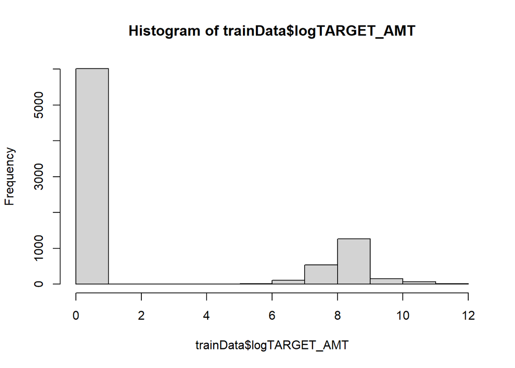

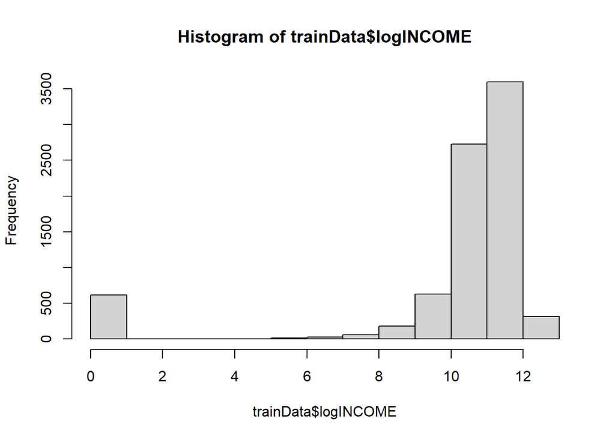

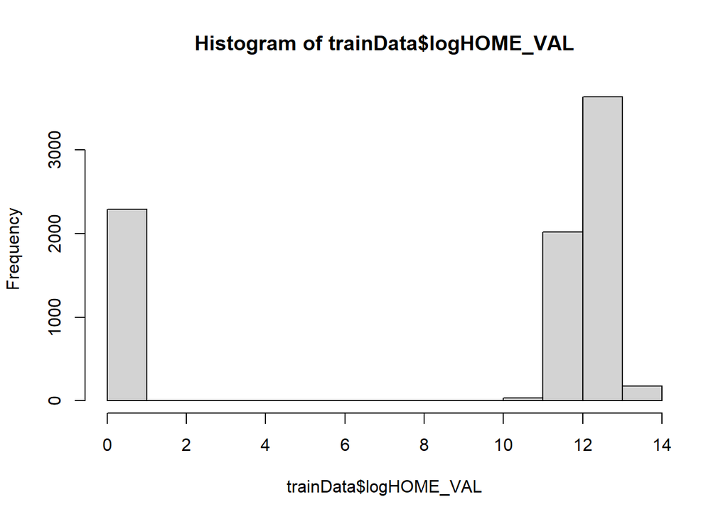

# Data Exploration Part II

Here is a new look at the training data with the corrected variable data types and adjusting NA values.

## Distributions

The following are the distributions for the variables:

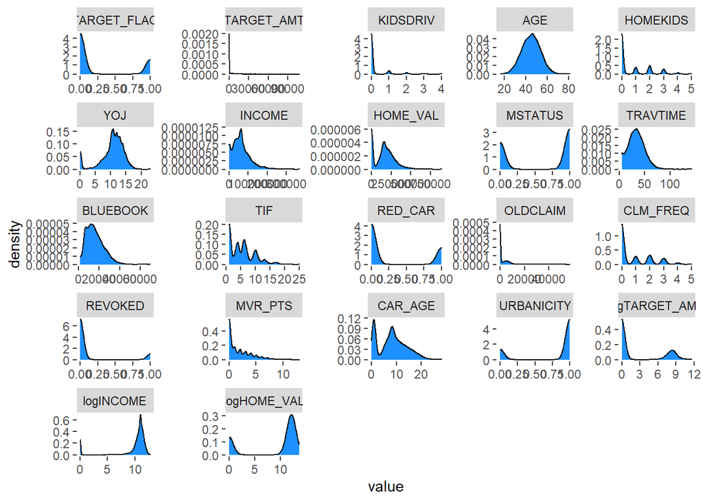

## Boxplots

The following is a plot of the boxplots for the variables:

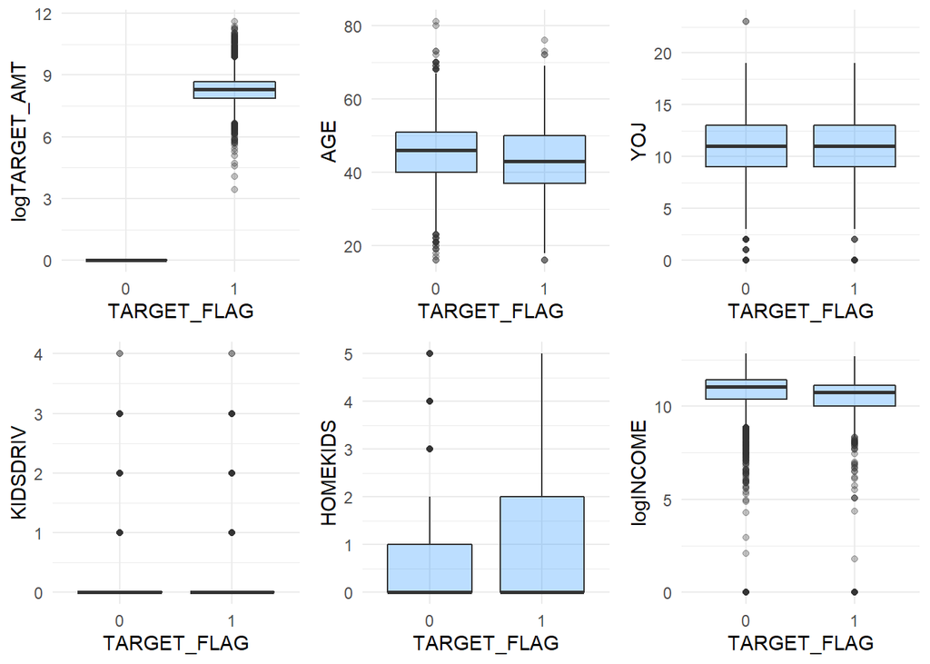

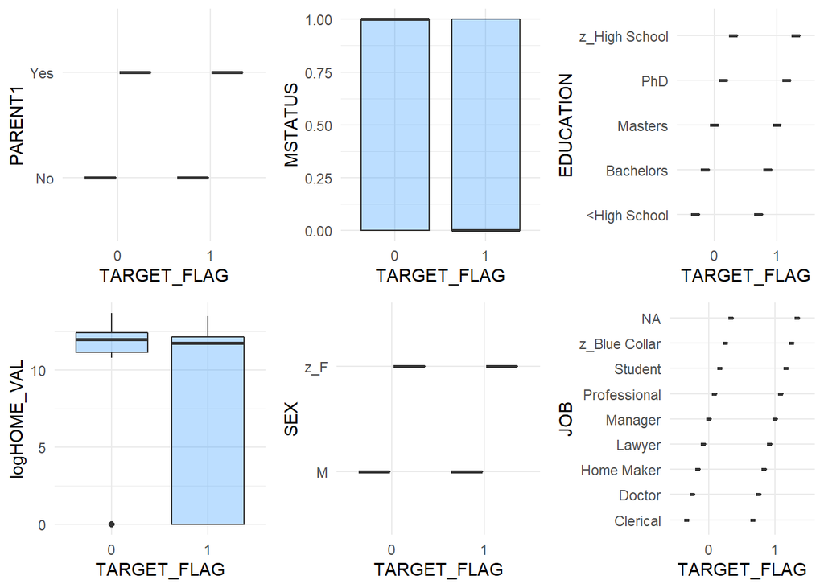

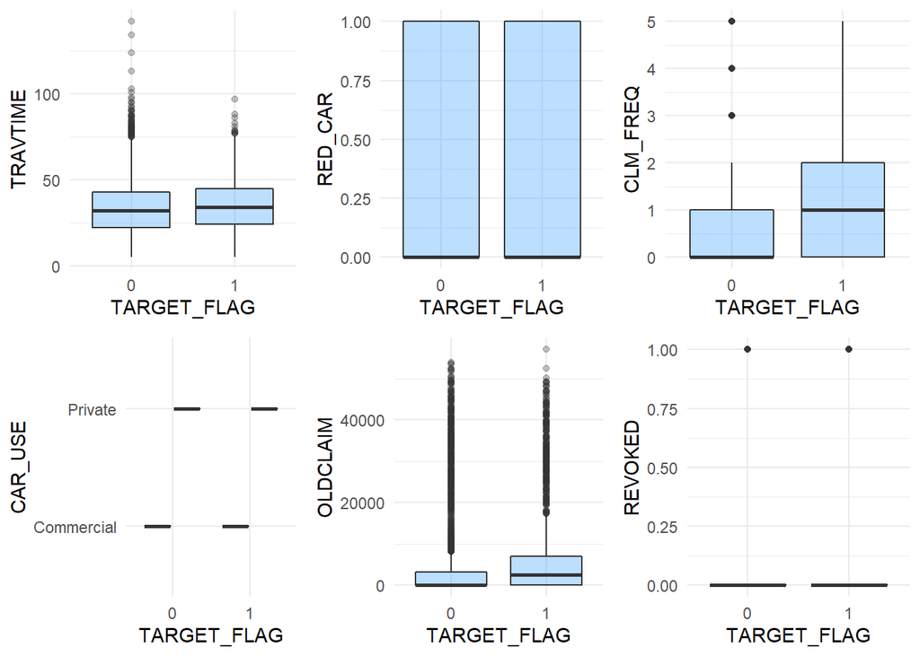

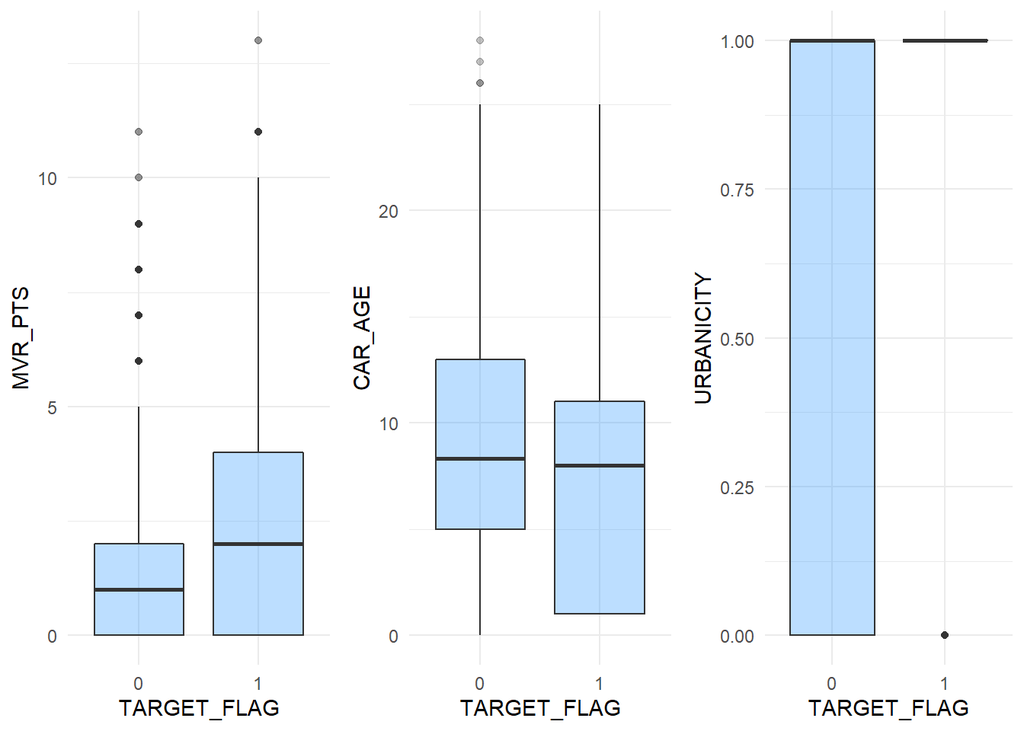

## Correlation

The following constructs a correlation matrix with heatmap. This matrix measures linear relationships between the variables. These values range from -1 to 1. If the value is close to -1, there is a strong negative correlation between the variables. If there is a value close to 1, there is a strong positive correlation between the variables.

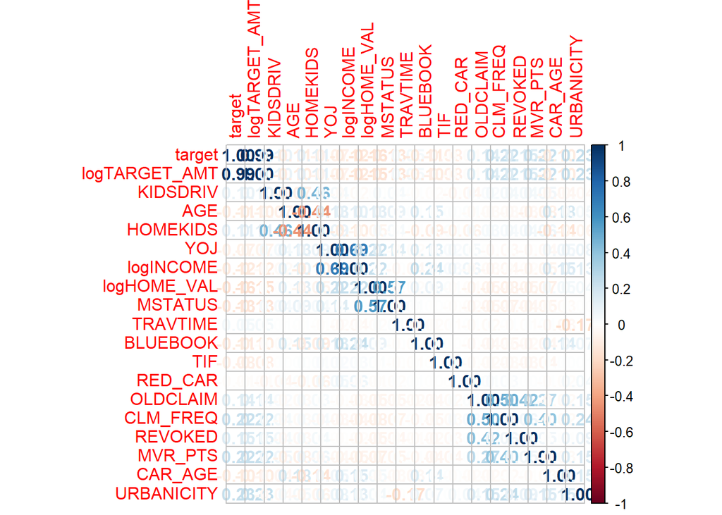

```
##               TARGET_FLAG TARGET_AMT  KIDSDRIV         AGE  HOMEKIDS       YOJ
## TARGET_FLAG      1.000000   0.534246  0.103668 -0.10312612  0.115621 -0.068488
## TARGET_AMT       0.534246   1.000000  0.055394 -0.04172275  0.061988 -0.020940
## KIDSDRIV         0.103668   0.055394  1.000000 -0.07517573  0.464015  0.041862
## AGE             -0.103126  -0.041723 -0.075176  1.00000000 -0.445094  0.131976
## HOMEKIDS         0.115621   0.061988  0.464015 -0.44509444  1.000000  0.084286
## YOJ             -0.068488  -0.020940  0.041862  0.13197602  0.084286  1.000000
## INCOME          -0.138243  -0.056640 -0.045870  0.17614003 -0.155238  0.270162
## HOME_VAL        -0.178477  -0.083554 -0.019359  0.20422035 -0.107807  0.255039
## MSTATUS         -0.135125  -0.087661  0.042461  0.09067531  0.043526  0.141641
## TRAVTIME         0.048368   0.027987  0.008447  0.00526795 -0.007246 -0.016497
## BLUEBOOK        -0.103383  -0.004700 -0.021549  0.16492292 -0.107894  0.139606
## TIF             -0.082370  -0.046481 -0.001989 -0.00006628  0.011813  0.024114
## RED_CAR         -0.006947   0.008092 -0.043638  0.02030543 -0.068148  0.049271
## OLDCLAIM         0.138084   0.070953  0.020403 -0.02927718  0.029911 -0.002903
## CLM_FREQ         0.216196   0.116419  0.037063 -0.02407730  0.029349 -0.025539
## REVOKED          0.151939   0.061385  0.043062 -0.03845823  0.045116 -0.006233
## MVR_PTS          0.219197   0.137866  0.053566 -0.07151886  0.060601 -0.036822
## CAR_AGE         -0.096943  -0.057614 -0.051798  0.17090989 -0.147376  0.057705
## URBANICITY       0.224251   0.120974 -0.037124  0.05133470 -0.063483  0.081578
## logTARGET_AMT    0.993527   0.602459  0.102341 -0.10113255  0.114757 -0.066980
## logINCOME       -0.115054  -0.036627 -0.024429  0.10810925 -0.111352  0.679798
## logHOME_VAL     -0.155423  -0.074564 -0.002413  0.12725665 -0.049027  0.218599
## target           1.000000   0.534246  0.103668 -0.10312612  0.115621 -0.068488
##                  INCOME  HOME_VAL    MSTATUS  TRAVTIME  BLUEBOOK         TIF
## TARGET_FLAG   -0.138243 -0.178477 -0.1351248  0.048368 -0.103383 -0.08237005
## TARGET_AMT    -0.056640 -0.083554 -0.0876612  0.027987 -0.004700 -0.04648083
## KIDSDRIV      -0.045870 -0.019359  0.0424609  0.008447 -0.021549 -0.00198871
## AGE            0.176140  0.204220  0.0906753  0.005268  0.164923 -0.00006628
## HOMEKIDS      -0.155238 -0.107807  0.0435259 -0.007246 -0.107894  0.01181332
## YOJ            0.270162  0.255039  0.1416408 -0.016497  0.139606  0.02411388
## INCOME         1.000000  0.543080 -0.0299020 -0.045641  0.418493 -0.00100849
## HOME_VAL       0.543080  1.000000  0.4462949 -0.034618  0.251812  0.00199698
## MSTATUS       -0.029902  0.446295  1.0000000  0.010248 -0.007743 -0.00074106
## TRAVTIME      -0.045641 -0.034618  0.0102483  1.000000 -0.017001 -0.01160463
## BLUEBOOK       0.418493  0.251812 -0.0077430 -0.017001  1.000000 -0.00542457
## TIF           -0.001008  0.001997 -0.0007411 -0.011605 -0.005425  1.00000000
## RED_CAR        0.057156  0.015747 -0.0192863  0.003966  0.021866 -0.00087168
## OLDCLAIM      -0.044197 -0.067312 -0.0459198 -0.019267 -0.029518 -0.02195820
## CLM_FREQ      -0.046550 -0.091435 -0.0693289  0.006560 -0.036341 -0.02302295
```

[output cut: 41 more lines]

```
## MSTATUS        -0.002562     -0.137143  0.0007755    0.573627 -0.135125
## TRAVTIME       -0.166005      0.047840 -0.0379887   -0.018599  0.048368
## BLUEBOOK        0.087741     -0.096537  0.2556318    0.081006 -0.103383
## TIF             0.007131     -0.082308  0.0261078    0.011410 -0.082370
## RED_CAR         0.046347     -0.004836  0.0712428   -0.011650 -0.006947
## OLDCLAIM        0.151083      0.137857 -0.0255546   -0.052823  0.138084
## CLM_FREQ        0.239125      0.213520 -0.0357093   -0.075636  0.216196
## REVOKED         0.085709      0.149822 -0.0179678   -0.051002  0.151939
## MVR_PTS         0.150243      0.220650 -0.0485838   -0.069283  0.219197
## CAR_AGE         0.164459     -0.095483  0.1770089    0.050610 -0.096943
## URBANICITY      1.000000      0.223324  0.1409872    0.043799  0.224251
## logTARGET_AMT   0.223324      1.000000 -0.1115970   -0.154221  0.993527
## logINCOME       0.140987     -0.111597  1.0000000    0.217606 -0.115054
## logHOME_VAL     0.043799     -0.154221  0.2176060    1.000000 -0.155423
## target          0.224251      0.993527 -0.1150544   -0.155423  1.000000
```

## Skewness

The following looks at the skewness of each of the variables:

```
##   TARGET_FLAG    TARGET_AMT      KIDSDRIV           AGE      HOMEKIDS
##        1.0719        8.7079        3.3525       -0.0290        1.3414
##           YOJ        INCOME      HOME_VAL       MSTATUS      TRAVTIME
##       -1.2381        1.2203        0.5032       -0.4069        0.4469
##      BLUEBOOK           TIF       RED_CAR      OLDCLAIM      CLM_FREQ
##        0.7944        0.8910        0.9182        3.1196        1.2090
##       REVOKED       MVR_PTS       CAR_AGE    URBANICITY logTARGET_AMT
##        2.3023        1.3481        0.2917       -1.4652        1.1154
##     logINCOME   logHOME_VAL        target
##       -2.8115       -0.9595        1.0719
```

## Splitting

I split the training data into two partitions.

| TARGET_FLAG | TARGET_AMT | KIDSDRIV | AGE | HOMEKIDS | YOJ | INCOME | PARENT1 | HOME_VAL | MSTATUS | SEX | EDUCATION | JOB | TRAVTIME | CAR_USE | BLUEBOOK | TIF | CAR_TYPE | RED_CAR | OLDCLAIM | CLM_FREQ | REVOKED | MVR_PTS | CAR_AGE | URBANICITY | logTARGET_AMT | logINCOME | logHOME_VAL | target |
| --- | --- | --- | --- | --- | --- | --- | --- | --- | --- | --- | --- | --- | --- | --- | --- | --- | --- | --- | --- | --- | --- | --- | --- | --- | --- | --- | --- | --- |
| 0 | 0 | 0 | 60 | 0 | 11.0 | 67349 | No | 0 | 0 | M | PhD | Professional | 14 | Private | 14230 | 11 | Minivan | 1 | 4461 | 2 | 0 | 3 | 18 | 1 | 0 | 11.118 | 0.00 | 0 |
| 0 | 0 | 0 | 43 | 0 | 11.0 | 91449 | No | 257252 | 0 | M | z_High School | z_Blue Collar | 22 | Commercial | 14940 | 1 | Minivan | 1 | 0 | 0 | 0 | 0 | 1 | 1 | 0 | 11.424 | 12.46 | 0 |
| 0 | 0 | 0 | 35 | 1 | 10.0 | 16039 | No | 124191 | 1 | z_F | z_High School | Clerical | 5 | Private | 4010 | 4 | z_SUV | 0 | 38690 | 2 | 0 | 3 | 10 | 1 | 0 | 9.683 | 11.73 | 0 |
| 0 | 0 | 0 | 51 | 0 | 14.0 | 61898 | No | 306251 | 1 | M | <High School | z_Blue Collar | 32 | Private | 15440 | 7 | Minivan | 1 | 0 | 0 | 0 | 0 | 6 | 1 | 0 | 11.033 | 12.63 | 0 |
| 0 | 0 | 0 | 50 | 0 | 10.5 | 114986 | No | 243925 | 1 | z_F | PhD | Doctor | 36 | Private | 18000 | 1 | z_SUV | 0 | 19217 | 2 | 1 | 3 | 17 | 1 | 0 | 11.653 | 12.40 | 0 |
| 0 | 0 | 0 | 54 | 0 | 10.5 | 18755 | No | 154867 | 1 | z_F | <High School | z_Blue Collar | 33 | Private | 8780 | 1 | z_SUV | 0 | 0 | 0 | 0 | 0 | 1 | 1 | 0 | 9.839 | 11.95 | 0 |

| TARGET_FLAG | TARGET_AMT | KIDSDRIV | AGE | HOMEKIDS | YOJ | INCOME | PARENT1 | HOME_VAL | MSTATUS | SEX | EDUCATION | JOB | TRAVTIME | CAR_USE | BLUEBOOK | TIF | CAR_TYPE | RED_CAR | OLDCLAIM | CLM_FREQ | REVOKED | MVR_PTS | CAR_AGE | URBANICITY | logTARGET_AMT | logINCOME | logHOME_VAL | target |
| --- | --- | --- | --- | --- | --- | --- | --- | --- | --- | --- | --- | --- | --- | --- | --- | --- | --- | --- | --- | --- | --- | --- | --- | --- | --- | --- | --- | --- |
| 1 | 2946 | 0 | 34 | 1 | 12 | 125301 | Yes | 0 | 0 | z_F | Bachelors | z_Blue Collar | 46 | Commercial | 17430 | 1 | Sports Car | 0 | 0 | 0 | 0 | 0 | 7 | 1 | 7.989 | 11.74 | 0.00 | 1 |
| 1 | 2501 | 0 | 34 | 0 | 10 | 62978 | No | 0 | 0 | z_F | Bachelors | Clerical | 34 | Private | 11200 | 1 | z_SUV | 0 | 0 | 0 | 0 | 0 | 1 | 1 | 7.825 | 11.05 | 0.00 | 1 |
| 1 | 6077 | 0 | 53 | 0 | 14 | 77100 | No | 0 | 0 | z_F | Masters | Lawyer | 15 | Private | 18300 | 1 | Sports Car | 0 | 0 | 0 | 0 | 0 | 11 | 1 | 8.712 | 11.25 | 0.00 | 1 |
| 0 | 0 | 0 | 39 | 3 | 12 | 51884 | Yes | 180951 | 0 | z_F | Bachelors | Clerical | 43 | Private | 10590 | 6 | z_SUV | 0 | 0 | 0 | 0 | 0 | 13 | 0 | 0.000 | 10.86 | 12.11 | 0 |
| 1 | 6857 | 0 | 28 | 1 | 13 | 44077 | No | 170598 | 1 | z_F | z_High School | z_Blue Collar | 29 | Commercial | 8710 | 6 | z_SUV | 0 | 8935 | 2 | 0 | 0 | 1 | 1 | 8.833 | 10.69 | 12.05 | 1 |
| 0 | 0 | 1 | 44 | 2 | 17 | 45488 | No | 219378 | 1 | M | Bachelors | Manager | 16 | Private | 22090 | 17 | Minivan | 0 | 0 | 0 | 0 | 0 | 12 | 1 | 0.000 | 10.73 | 12.30 | 0 |

# Models

In developing the models, I used the `leaps` [package](https://cran.r-project.org/web/packages/leaps/leaps.pdf). According to the documentation, “leaps() performs an exhaustive search for the best subsets of the variables in x for predicting y in linear regression, using an efficient branch-and-bound algorithm.”

## 1st Model

For the 1st model, I decided to use the variables `SEX`, `logINCOME`, and `logHOME_VAL`. Here is a summary of the model:

```
##
## Call:
## glm(formula = target ~ SEX + logINCOME + logHOME_VAL, family = "binomial",
##     data = training)
##
## Deviance Residuals:
##    Min      1Q  Median      3Q     Max
## -1.197  -0.719  -0.683   1.158   1.853
##
## Coefficients:
##             Estimate Std. Error z value             Pr(>|z|)
## (Intercept) -0.02704    0.10250   -0.26                 0.79
## SEXz_F       0.07378    0.05832    1.27                 0.21
## logINCOME   -0.06477    0.00898   -7.21     0.00000000000056 ***
## logHOME_VAL -0.05078    0.00508   -9.99 < 0.0000000000000002 ***
## ---
## Signif. codes:  0 '***' 0.001 '**' 0.01 '*' 0.05 '.' 0.1 ' ' 1
##
## (Dispersion parameter for binomial family taken to be 1)
##
##     Null deviance: 7465.1  on 6528  degrees of freedom
## Residual deviance: 7271.4  on 6525  degrees of freedom
## AIC: 7279
##
## Number of Fisher Scoring iterations: 4
```

Now, let’s look at how the model works with our test data.

|  | actual | predictedProb | prediction |
| --- | --- | --- | --- |
| 1 | 1 | 0.3288 | 0 |
| 2 | 1 | 0.3387 | 0 |
| 3 | 1 | 0.3358 | 0 |
| 4 | 0 | 0.2191 | 0 |
| 5 | 1 | 0.2214 | 0 |
| 6 | 0 | 0.2065 | 0 |

```
## Confusion Matrix and Statistics
##
##           Reference
## Prediction    0    1
##          0 1144  446
##          1   24   18
##
##                Accuracy : 0.712
##                  95% CI : (0.689, 0.734)
##     No Information Rate : 0.716
##     P-Value [Acc > NIR] : 0.641
##
##                   Kappa : 0.025
##
##  Mcnemar's Test P-Value : <0.0000000000000002
##
##             Sensitivity : 0.0388
##             Specificity : 0.9795
##          Pos Pred Value : 0.4286
##          Neg Pred Value : 0.7195
##              Prevalence : 0.2843
##          Detection Rate : 0.0110
##    Detection Prevalence : 0.0257
##       Balanced Accuracy : 0.5091
##
##        'Positive' Class : 1
##
```

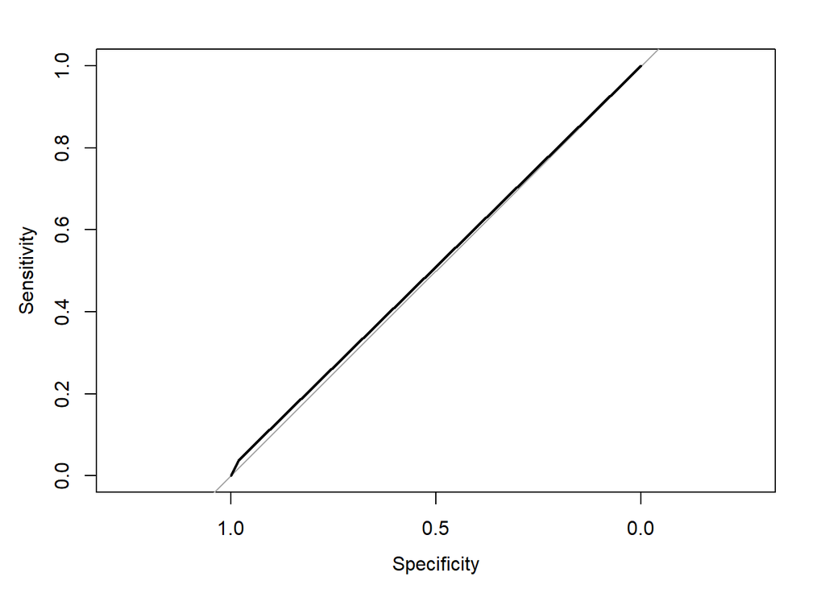

```
## Area under the curve: 0.509
```

## Second Model

For the 2nd model, I decided to use the variables `SEX`, AGE`,`RED_CAR`,`URBANICITY`,`CAR_TYPE`, and`YOJ`. Here is a summary of the model:

```
##
## Call:
## glm(formula = target ~ SEX + AGE + RED_CAR + URBANICITY + CAR_TYPE +
##     YOJ, family = "binomial", data = training)
##
## Deviance Residuals:
##    Min      1Q  Median      3Q     Max
## -1.405  -0.852  -0.576   1.098   2.974
##
## Coefficients:
##                     Estimate Std. Error z value             Pr(>|z|)
## (Intercept)         -1.67571    0.21324   -7.86   0.0000000000000039 ***
## SEXz_F              -0.26204    0.10632   -2.46                0.014 *
## AGE                 -0.02888    0.00349   -8.27 < 0.0000000000000002 ***
## RED_CAR              0.08127    0.08958    0.91                0.364
## URBANICITY           1.98835    0.11529   17.25 < 0.0000000000000002 ***
## CAR_TYPEPanel Truck  0.55266    0.12563    4.40   0.0000108788562117 ***
## CAR_TYPEPickup       0.90277    0.09629    9.38 < 0.0000000000000002 ***
## CAR_TYPESports Car   1.24969    0.12440   10.05 < 0.0000000000000002 ***
## CAR_TYPEVan          0.55309    0.11819    4.68   0.0000028715420852 ***
## CAR_TYPEz_SUV        1.10195    0.10486   10.51 < 0.0000000000000002 ***
## YOJ                 -0.04138    0.00753   -5.50   0.0000000382949954 ***
## ---
## Signif. codes:  0 '***' 0.001 '**' 0.01 '*' 0.05 '.' 0.1 ' ' 1
##
## (Dispersion parameter for binomial family taken to be 1)
##
##     Null deviance: 7465.1  on 6528  degrees of freedom
## Residual deviance: 6768.9  on 6518  degrees of freedom
## AIC: 6791
##
## Number of Fisher Scoring iterations: 5
```

Now, let’s look at how the model works with our test data.

|  | actual | predictedProb | prediction |
| --- | --- | --- | --- |
| 1 | 1 | 0.4556 | 0 |
| 2 | 1 | 0.4395 | 0 |
| 3 | 1 | 0.3079 | 0 |
| 4 | 0 | 0.0788 | 0 |
| 5 | 1 | 0.4516 | 0 |
| 6 | 0 | 0.1595 | 0 |

```
## Confusion Matrix and Statistics
##
##           Reference
## Prediction    0    1
##          0 1147  429
##          1   21   35
##
##                Accuracy : 0.724
##                  95% CI : (0.702, 0.746)
##     No Information Rate : 0.716
##     P-Value [Acc > NIR] : 0.23
##
##                   Kappa : 0.078
##
##  Mcnemar's Test P-Value : <0.0000000000000002
##
##             Sensitivity : 0.0754
##             Specificity : 0.9820
##          Pos Pred Value : 0.6250
##          Neg Pred Value : 0.7278
##              Prevalence : 0.2843
##          Detection Rate : 0.0214
##    Detection Prevalence : 0.0343
##       Balanced Accuracy : 0.5287
##
##        'Positive' Class : 1
##
```

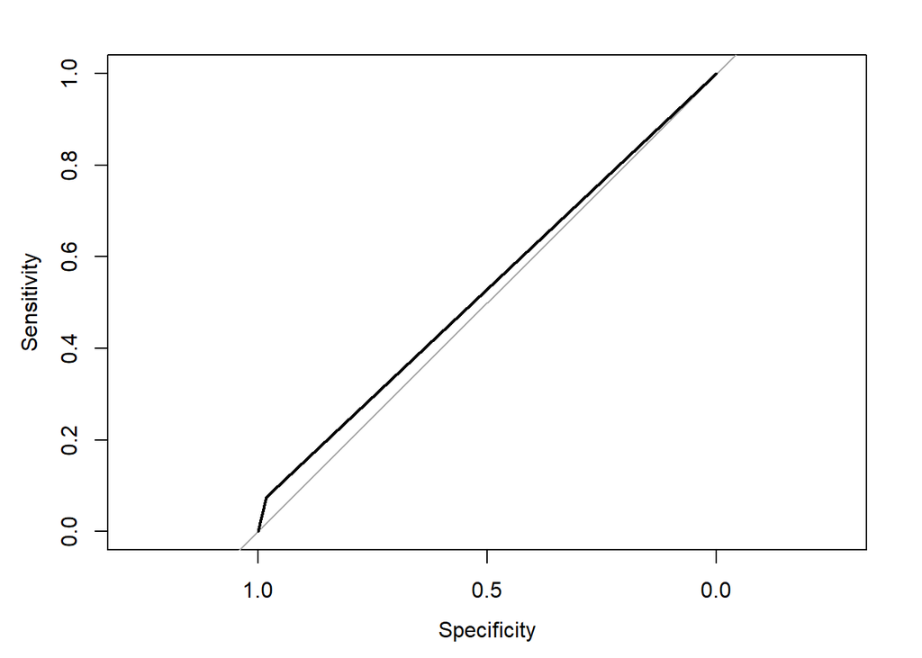

```
## Area under the curve: 0.529
```

## Third Model

For the 3rd model, I decided to use the variables `SEX`, AGE`,`RED_CAR`,`URBANICITY`,`CAR_TYPE`,`EDUCATION`,`KIDSDRIV`,`CAR_USE`, MSTATUS`, `MVR_PTS`, `JOB`, TIF`, and`YOJ`. Here is a summary of the model:

```
##
## Call:
## glm(formula = target ~ SEX + AGE + RED_CAR + URBANICITY + CAR_TYPE +
##     EDUCATION + KIDSDRIV + MSTATUS + MVR_PTS + CAR_USE + JOB +
##     TIF + YOJ, family = "binomial", data = training)
##
## Deviance Residuals:
##    Min      1Q  Median      3Q     Max
## -2.093  -0.722  -0.423   0.671   3.130
##
## Coefficients:
##                        Estimate Std. Error z value             Pr(>|z|)
## (Intercept)            -1.67476    0.28589   -5.86    0.000000004684837 ***
## SEXz_F                 -0.30510    0.11934   -2.56              0.01057 *
## AGE                    -0.00929    0.00403   -2.31              0.02099 *
## RED_CAR                -0.04355    0.10272   -0.42              0.67162
## URBANICITY              2.33424    0.12266   19.03 < 0.0000000000000002 ***
## CAR_TYPEPanel Truck     0.16653    0.17384    0.96              0.33809
## CAR_TYPEPickup          0.59562    0.11247    5.30    0.000000118453107 ***
## CAR_TYPESports Car      1.24573    0.13535    9.20 < 0.0000000000000002 ***
## CAR_TYPEVan             0.35467    0.14059    2.52              0.01165 *
## CAR_TYPEz_SUV           1.05584    0.11404    9.26 < 0.0000000000000002 ***
## EDUCATIONBachelors     -0.47195    0.11815   -3.99    0.000064816255051 ***
## EDUCATIONMasters       -0.31919    0.18058   -1.77              0.07713 .
## EDUCATIONPhD           -0.12451    0.22520   -0.55              0.58034
## EDUCATIONz_High School -0.00390    0.10495   -0.04              0.97034
## KIDSDRIV                0.45371    0.05909    7.68    0.000000000000016 ***
## MSTATUS                -0.71826    0.06888  -10.43 < 0.0000000000000002 ***
## MVR_PTS                 0.15718    0.01464   10.74 < 0.0000000000000002 ***
## CAR_USEPrivate         -0.76803    0.10287   -7.47    0.000000000000083 ***
## JOBDoctor              -1.40009    0.32180   -4.35    0.000013561414415 ***
## JOBHome Maker           0.05350    0.15579    0.34              0.73129
## JOBLawyer              -0.51355    0.20240   -2.54              0.01117 *
## JOBManager             -1.15864    0.15796   -7.33    0.000000000000222 ***
## JOBProfessional        -0.44836    0.13611   -3.29              0.00099 ***
## JOBStudent              0.14434    0.14033    1.03              0.30368
## JOBz_Blue Collar       -0.18395    0.11675   -1.58              0.11512
## TIF                    -0.05536    0.00837   -6.61    0.000000000038010 ***
## YOJ                    -0.01166    0.00939   -1.24              0.21430
## ---
## Signif. codes:  0 '***' 0.001 '**' 0.01 '*' 0.05 '.' 0.1 ' ' 1
##
## (Dispersion parameter for binomial family taken to be 1)
##
##     Null deviance: 7013.2  on 6132  degrees of freedom
## Residual deviance: 5594.8  on 6106  degrees of freedom
##   (396 observations deleted due to missingness)
## AIC: 5649
##
## Number of Fisher Scoring iterations: 5
```

Now, let’s look at how the model works with our test data.

|  | actual | predictedProb | prediction |
| --- | --- | --- | --- |
| 1 | 1 | 0.60661 | 1 |
| 2 | 1 | 0.42127 | 0 |
| 3 | 1 | 0.32924 | 0 |
| 4 | 0 | 0.04750 | 0 |
| 5 | 1 | 0.44035 | 0 |
| 6 | 0 | 0.02787 | 0 |

```
## Confusion Matrix and Statistics
##
##           Reference
## Prediction   0   1
##          0 985 274
##          1  87 156
##
##                Accuracy : 0.76
##                  95% CI : (0.737, 0.781)
##     No Information Rate : 0.714
##     P-Value [Acc > NIR] : 0.0000353
##
##                   Kappa : 0.324
##
##  Mcnemar's Test P-Value : < 0.0000000000000002
##
##             Sensitivity : 0.363
##             Specificity : 0.919
##          Pos Pred Value : 0.642
##          Neg Pred Value : 0.782
##              Prevalence : 0.286
##          Detection Rate : 0.104
##    Detection Prevalence : 0.162
##       Balanced Accuracy : 0.641
##
##        'Positive' Class : 1
##
```

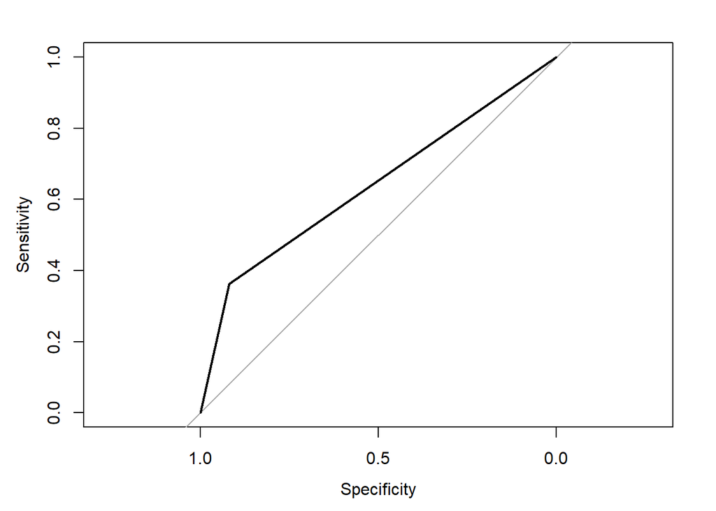

```
## Area under the curve: 0.641
```

## Fourth Model

For the 4th model, I decided to use the variables `AGE`, `SEX`, `MSTATUS`, `CLM_FREQ`, `REVOKED`, `MVR_PTS`, `TRAVTIME`, and `CAR_USE`. Here is a summary of the model:

```
##
## Call:
## glm(formula = target ~ AGE + SEX + MSTATUS + CLM_FREQ + REVOKED +
##     MVR_PTS + TRAVTIME + CAR_USE, family = "binomial", data = training)
##
## Deviance Residuals:
##    Min      1Q  Median      3Q     Max
## -2.061  -0.749  -0.560   0.823   2.394
##
## Coefficients:
##                Estimate Std. Error z value             Pr(>|z|)
## (Intercept)    -0.63685    0.18231   -3.49              0.00048 ***
## AGE            -0.01880    0.00353   -5.32  0.00000010474838359 ***
## SEXz_F          0.33345    0.06401    5.21  0.00000018975671632 ***
## MSTATUS        -0.49560    0.06087   -8.14  0.00000000000000039 ***
## CLM_FREQ        0.25764    0.02613    9.86 < 0.0000000000000002 ***
## REVOKED         0.86594    0.08390   10.32 < 0.0000000000000002 ***
## MVR_PTS         0.15413    0.01423   10.83 < 0.0000000000000002 ***
## TRAVTIME        0.00785    0.00192    4.10  0.00004191086393955 ***
## CAR_USEPrivate -0.67165    0.06400  -10.50 < 0.0000000000000002 ***
## ---
## Signif. codes:  0 '***' 0.001 '**' 0.01 '*' 0.05 '.' 0.1 ' ' 1
##
## (Dispersion parameter for binomial family taken to be 1)
##
##     Null deviance: 7465.1  on 6528  degrees of freedom
## Residual deviance: 6677.9  on 6520  degrees of freedom
## AIC: 6696
##
## Number of Fisher Scoring iterations: 4
```

Now, let’s look at how the model works with our test data.

|  | actual | predictedProb | prediction |
| --- | --- | --- | --- |
| 1 | 1 | 0.35861 | 0 |
| 2 | 1 | 0.20632 | 0 |
| 3 | 1 | 0.13546 | 0 |
| 4 | 0 | 0.20253 | 0 |
| 5 | 1 | 0.35838 | 0 |
| 6 | 0 | 0.07547 | 0 |

```
## Confusion Matrix and Statistics
##
##           Reference
## Prediction    0    1
##          0 1110  370
##          1   58   94
##
##                Accuracy : 0.738
##                  95% CI : (0.716, 0.759)
##     No Information Rate : 0.716
##     P-Value [Acc > NIR] : 0.025
##
##                   Kappa : 0.192
##
##  Mcnemar's Test P-Value : <0.0000000000000002
##
##             Sensitivity : 0.2026
##             Specificity : 0.9503
##          Pos Pred Value : 0.6184
##          Neg Pred Value : 0.7500
##              Prevalence : 0.2843
##          Detection Rate : 0.0576
##    Detection Prevalence : 0.0931
##       Balanced Accuracy : 0.5765
##
##        'Positive' Class : 1
##
```

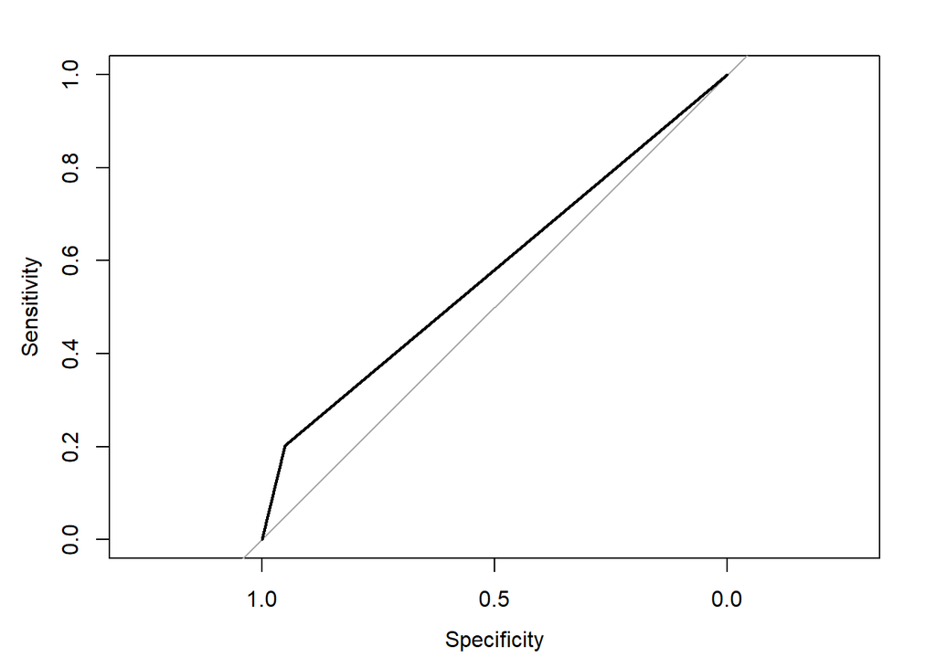

```
## Area under the curve: 0.576
```

# Multiple Linear Regression

This section goes about attempting to establish a model for estimating the cost if a person crashes their car.

## First Model

```
##
## Call:
## lm(formula = TARGET_AMT ~ BLUEBOOK + CAR_AGE + CAR_TYPE + logINCOME,
##     data = training)
##
## Residuals:
##    Min     1Q Median     3Q    Max
##  -3103  -1633  -1178   -434 105632
##
## Coefficients:
##                       Estimate Std. Error t value          Pr(>|t|)
## (Intercept)         1899.88850  250.03587    7.60 0.000000000000034 ***
## BLUEBOOK              -0.00327    0.00835   -0.39           0.69528
## CAR_AGE              -39.05623   10.41290   -3.75           0.00018 ***
## CAR_TYPEPanel Truck 1340.20943  249.15242    5.38 0.000000077473796 ***
## CAR_TYPEPickup       687.64582  176.14001    3.90 0.000095580791750 ***
## CAR_TYPESports Car   686.55311  203.13864    3.38           0.00073 ***
## CAR_TYPEVan          890.52290  215.58244    4.13 0.000036606015179 ***
## CAR_TYPEz_SUV        485.83341  153.66654    3.16           0.00158 **
## logINCOME            -58.93278   19.84009   -2.97           0.00299 **
## ---
## Signif. codes:  0 '***' 0.001 '**' 0.01 '*' 0.05 '.' 0.1 ' ' 1
##
## Residual standard error: 4500 on 6520 degrees of freedom
## Multiple R-squared:  0.0111, Adjusted R-squared:  0.00987
## F-statistic: 9.14 on 8 and 6520 DF,  p-value: 0.00000000000141
```

Now, let’s look at how the model works with our test data.

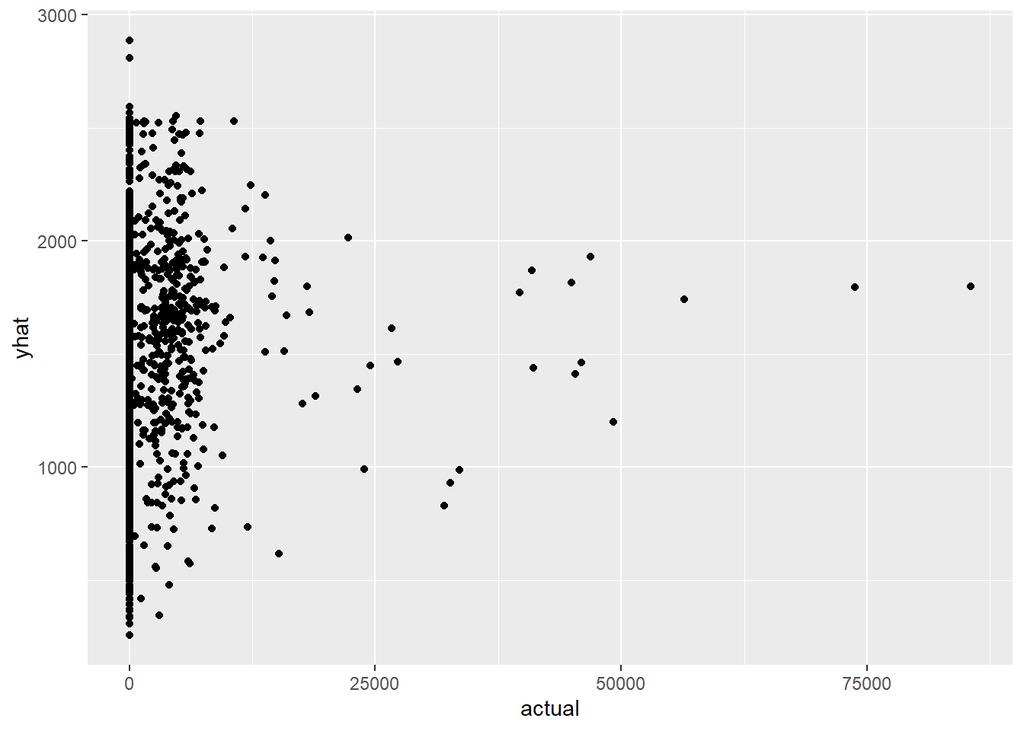

## Second Model

This second model estimates the cost using the `EDUCATION`, `BLUEBOOK`, `CAR_AGE`, `CAR_TYPE`, `TRAVTIME`, `logINCOME`, and `logHOME_VAL` variables.

```
##
## Call:
## lm(formula = TARGET_AMT ~ EDUCATION + BLUEBOOK + CAR_AGE + CAR_TYPE +
##     TRAVTIME + logINCOME + logHOME_VAL, data = training)
##
## Residuals:
##    Min     1Q Median     3Q    Max
##  -3487  -1615  -1106   -300 105798
##
## Coefficients:
##                          Estimate Std. Error t value      Pr(>|t|)
## (Intercept)            1876.77499  305.75827    6.14 0.00000000088 ***
## EDUCATIONBachelors      -40.19519  197.48180   -0.20       0.83872
## EDUCATIONMasters         18.67865  243.72117    0.08       0.93891
## EDUCATIONPhD            -97.79802  282.98995   -0.35       0.72966
## EDUCATIONz_High School   82.11797  180.15423    0.46       0.64853
## BLUEBOOK                 -0.00153    0.00841   -0.18       0.85556
## CAR_AGE                 -35.14723   14.24358   -2.47       0.01363 *
## CAR_TYPEPanel Truck    1322.22088  248.92760    5.31 0.00000011222 ***
## CAR_TYPEPickup          687.16521  175.93785    3.91 0.00009489251 ***
## CAR_TYPESports Car      697.90029  202.80849    3.44       0.00058 ***
## CAR_TYPEVan             886.96322  215.36266    4.12 0.00003861262 ***
## CAR_TYPEz_SUV           472.81194  153.41337    3.08       0.00207 **
## TRAVTIME                  6.10458    3.54983    1.72       0.08554 .
## logINCOME               -34.23380   20.49392   -1.67       0.09488 .
## logHOME_VAL             -56.02795   10.44877   -5.36 0.00000008506 ***
## ---
## Signif. codes:  0 '***' 0.001 '**' 0.01 '*' 0.05 '.' 0.1 ' ' 1
##
## Residual standard error: 4500 on 6514 degrees of freedom
## Multiple R-squared:  0.0161, Adjusted R-squared:  0.014
## F-statistic:  7.6 on 14 and 6514 DF,  p-value: 0.000000000000000393
```

Now, let’s look at how the model works with our test data.

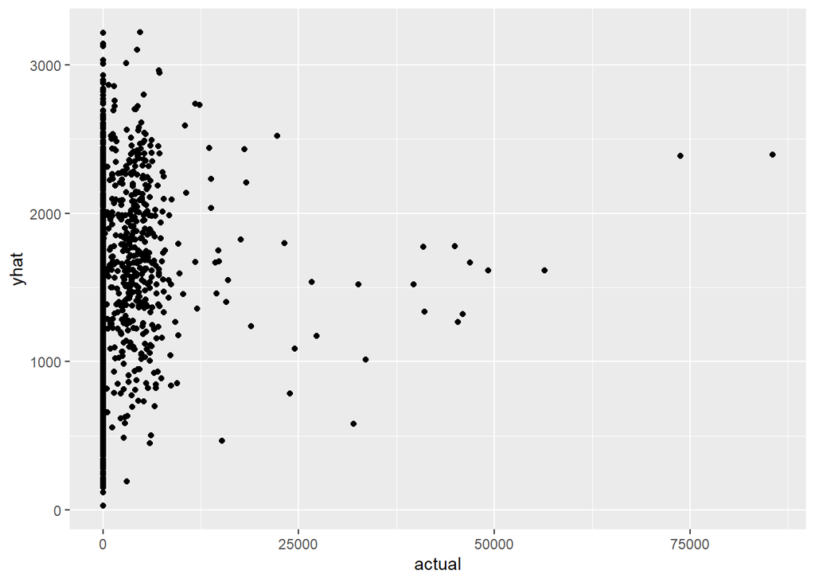

## Third Model

This third model estimates the cost using `BLUEBOOK` + `CAR_AGE` + `TRAVTIME` variables.

```
##
## Call:
## lm(formula = TARGET_AMT ~ BLUEBOOK + CAR_AGE + TRAVTIME, data = training)
##
## Residuals:
##    Min     1Q Median     3Q    Max
##  -2509  -1560  -1313   -654 105819
##
## Coefficients:
##               Estimate Std. Error t value            Pr(>|t|)
## (Intercept) 1505.12901  184.11110    8.18 0.00000000000000035 ***
## BLUEBOOK       0.00453    0.00681    0.66               0.506
## CAR_AGE      -44.01625   10.34537   -4.25 0.00002122753948791 ***
## TRAVTIME       7.09624    3.56144    1.99               0.046 *
## ---
## Signif. codes:  0 '***' 0.001 '**' 0.01 '*' 0.05 '.' 0.1 ' ' 1
##
## Residual standard error: 4520 on 6525 degrees of freedom
## Multiple R-squared:  0.00347,    Adjusted R-squared:  0.00301
## F-statistic: 7.58 on 3 and 6525 DF,  p-value: 0.0000467
```

Now, let’s look at how the model works with our test data.

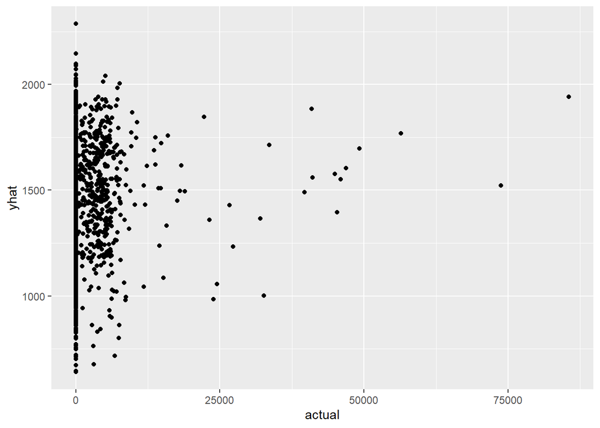

# Model Selection

For classification, the 3rd model had the best auc score. For the multiple linear regression, the 2nd model have a better $R^2$ measurement.

# Predictions

This section, runs the models on the evaluation data.

|  | actual | predictedProb | prediction |
| --- | --- | --- | --- |
| 1 | NA | 0.60661 | 1 |
| 2 | NA | 0.42127 | 0 |
| 3 | NA | 0.32924 | 0 |
| 4 | NA | 0.04750 | 0 |
| 5 | NA | 0.44035 | 0 |
| 6 | NA | 0.02787 | 0 |

This runs the evaluation data with the multiple linear regression model.

|  | prediction | actual |
| --- | --- | --- |
| 1 | 2125 | NA |
| 2 | 1652 | NA |
| 3 | 1889 | NA |
| 4 | 2602 | NA |
| 5 | 1785 | NA |
| 6 | 1678 | NA |